# Shortraker Rockfish

*Sebastes borealis*

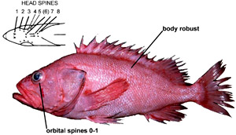

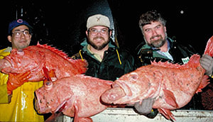

**Body color:** Pink to orange-pink; fins reddish, typically edged w/ black; dusky red bars may be present on back, these prominent in young specimens.

**Peritoneum color:** light w/ black dots **Shape between eyes:** convex to flat

**Counts:** D:XIII,12-15, Ar:6-8, P1:17-20, GR:27-31, LLp:28-32, LLs:36-46, V:27-28

**Occurence:** Bering Sea - Southern California

**Depth:** 100-875 meters **Size:** 108 cm **Species code:** 30576

**Similar species:**

- *Blackgill rockfish* - body red w/ black mouth, upper branchiostegal membranes, and gill cavity; peritoneum black; gillrakers typically 30-34 (27-31 in Shortraker RF)
- *Rougheye rockfish* - 2-10 spines below eye; body typically red w/ black mottling; gill rakers on first arch longer in individuals > 40 cm
- *Pacific Ocean Perch* - head spines weak and differ in count; prominent symphyseal knob; discrete dorsal blotches at base of dorsal fin; body shape slender
- *Sharpchin rockfish* - symphyseal knob prominent; discrete blotches w/ at least one crossing lateral line; head spines differ in count; anal spine 2 longer than 3
- *Redbanded rockfish* - body w/ five bands crossing lateral line; head spine count differs; anal spine 2 longer than 3; peritoneum dark

Back to Group

**Corrections:** If you see mistakes or want to suggest changes, please create an [issue](https://github.com/zoyafuso-NOAA/RACE_Survey_App/issues) on the source repository or

*reach out to Liz Dawson (Liz.Dawson AT noaa.gov).*